# GA2

Gangyan Liu, Dijia Tang, Chen Chen

```r
library(stats)
library(mice)
library(tidyverse)
library(factoextra)
```

# Part I

### Import data

```r
raw <- read_csv('https://s3.amazonaws.com/notredame.analytics.data/mallcustomers.csv')
customer <- raw
```

### Change the data type for each column

```r
customer <- customer %>%
  mutate(CustomerID = as.integer(CustomerID),Gender = as.factor(Gender),
         Age = as.integer(Age),Income = as.character(Income),SpendingScore = as.integer(SpendingScore))
```

# Part II

### Look at missing values

```r
summary(customer)
```

```
##    CustomerID        Gender        Age           Income
##  Min.   :  1.00   Female:90   Min.   :18.00   Length:200
##  1st Qu.: 50.75   Male  :76   1st Qu.:28.75   Class :character
##  Median :100.50   NA's  :34   Median :36.00   Mode  :character
##  Mean   :100.50               Mean   :38.85
##  3rd Qu.:150.25               3rd Qu.:49.00
##  Max.   :200.00               Max.   :70.00
##  SpendingScore
##  Min.   : 1.00
##  1st Qu.:34.75
##  Median :50.00
##  Mean   :50.20
##  3rd Qu.:73.00
##  Max.   :99.00
```

### Do the imputation based on logistic regression

```r
imputed_cust <- mice(customer,m=1,maxit=5,meth='logreg',seed=1234)
```

### First 10 suggested imputations of Gender

```r
imputed_cust$imp$Gender[1:10,]
```

```
##  [1] Female Female Female Female Female Female Female Male   Female Female
## Levels: Female Male
```

### Complete the customer dataset with the imputed values

```r
complete_cust <- mice::complete(imputed_cust)
```

### Change the Income column to numbers

```r
complete_cust$Income <-  str_remove_all(complete_cust$Income,' USD|,')
complete_cust <- complete_cust %>%
  mutate(Income = as.numeric(Income))
summary(complete_cust)
```

```
##    CustomerID        Gender         Age            Income
##  Min.   :  1.00   Female:111   Min.   :18.00   Min.   : 15000
##  1st Qu.: 50.75   Male  : 89   1st Qu.:28.75   1st Qu.: 41500
##  Median :100.50                Median :36.00   Median : 61500
##  Mean   :100.50                Mean   :38.85   Mean   : 60560
##  3rd Qu.:150.25                3rd Qu.:49.00   3rd Qu.: 78000
##  Max.   :200.00                Max.   :70.00   Max.   :137000
##  SpendingScore
##  Min.   : 1.00
##  1st Qu.:34.75
##  Median :50.00
##  Mean   :50.20
##  3rd Qu.:73.00
##  Max.   :99.00
```

# Part III

### Normalize the data using z-score

```r
selected_metrics <- complete_cust %>%
  select(-CustomerID, -Gender, -Age)
sm_z <- scale(selected_metrics)
```

### Cluster sm_z based on selected metrics

```r
set.seed(1234)
k_3 <- kmeans(sm_z, centers=3, nstart = 25)
k_3$size
```

```
## [1] 123  39  38
```

```r
k_3$centers
```

```
##       Income SpendingScore
## 1 -0.6246222   -0.01435636
## 2  0.9891010    1.23640011
## 3  1.0066735   -1.22246770
```

### Viz with fviz_cluster

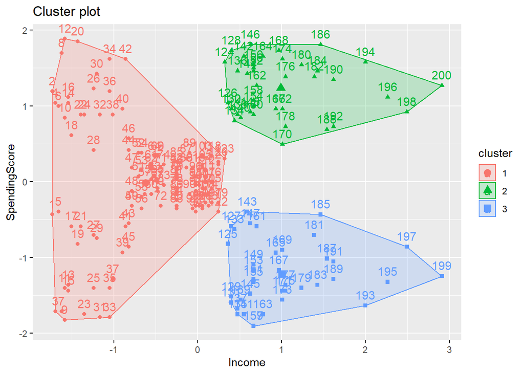

```r
fviz_cluster(k_3, data = sm_z)
```

### Assign cluster IDs to complete_cust

```r
complete_cust$cluster <- k_3$cluster
```

### Use the elbow method to identify the optimal number of clusters

```r
wcss <- vector()
n = 20
set.seed(1234)
for(k in 1:n) {
  wcss[k] <- sum(kmeans(sm_z, k)$withinss)
}

wcss
```

```
##  [1] 398.00000 272.68128 156.91549 108.37671  65.24057  54.78206  44.64043
##  [8]  40.45087  48.02401  38.71335  31.85579  27.65295  23.45477  22.81869
## [15]  22.44992  18.36966  16.35522  16.14122  15.68263  16.78943
```

### Visualize the values of WCSS as they relate to number of clusters

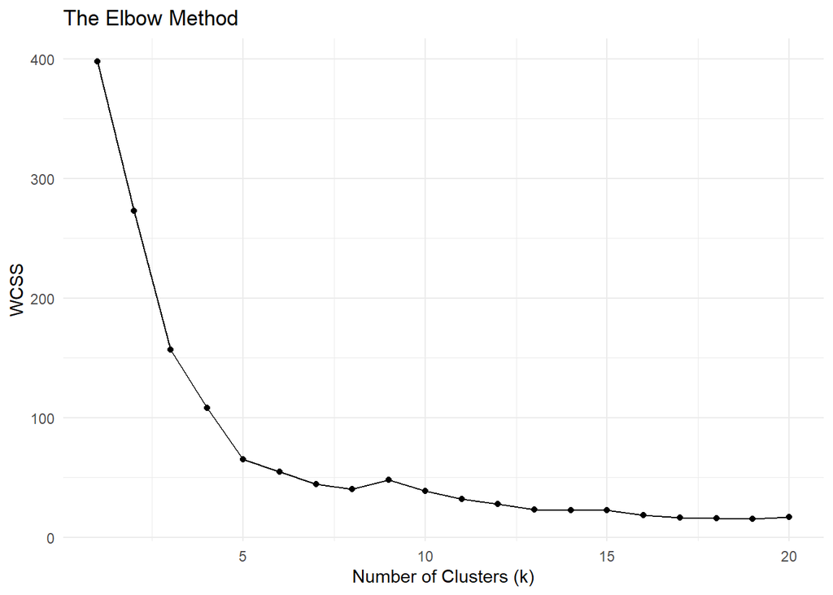

```r
tibble(value = wcss) %>%
  ggplot(mapping=aes(x=seq(1,length(wcss)), y=value)) +
  geom_point()+
  geom_line() +
  labs(title = "The Elbow Method", y = "WCSS", x = "Number of Clusters (k)" ) +
  theme_minimal()
```

### The optimal number of clusters should be 5 according to the elbow method.

# Part IV

### Use the optimal number of clusters and re-run the clustering

```r
set.seed(1234)
k_5 <- kmeans(sm_z, centers=5, nstart = 25)
k_5$size
```

```
## [1] 22 81 35 39 23
```

```r
k_5$centers
```

```
##       Income SpendingScore
## 1 -1.3262173    1.12934389
## 2 -0.2004097   -0.02638995
## 3  1.0523622   -1.28122394
## 4  0.9891010    1.23640011
## 5 -1.3042458   -1.13411939
```

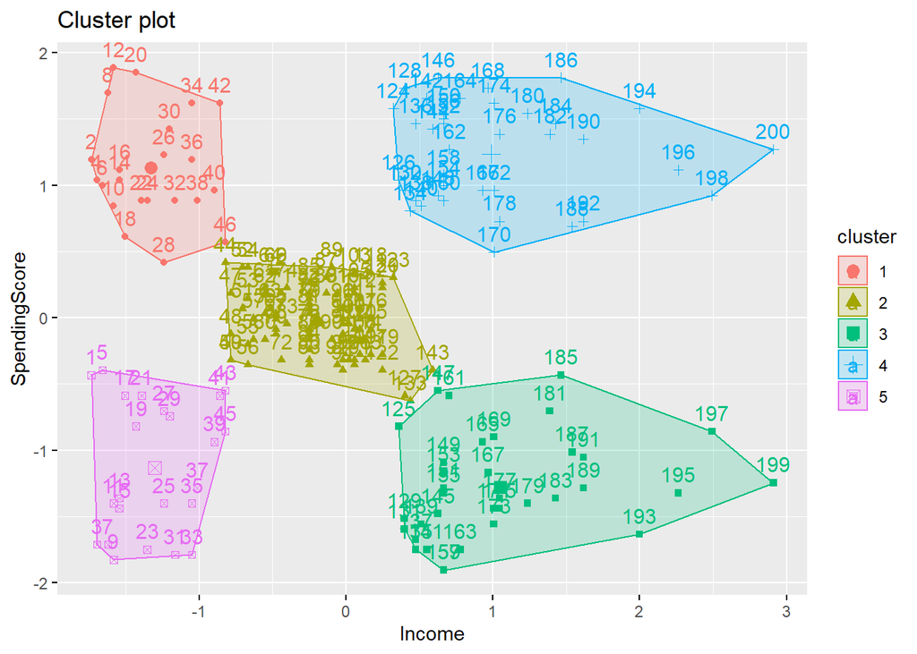

```r
fviz_cluster(k_5, data = sm_z)
```

### Looking at the above chart, we can assign the following labels to each cluster:

### **Cluster 1**: ‘Poor spenders’

### **Cluster 2**: ‘Neutral middle-class’

### **Cluster 3**: ‘Rich savers’

### **Cluster 4**: ‘Rich spenders’

### **Cluster 5**: ‘Poor savers’

### Create a new column in complete_cust to show the cluster number

```r
complete_cust$cluster <- k_5$cluster
```

### Examine age and gender for each cluster

```r
cluster_age_gender <- complete_cust %>%
  select(cluster,Age,Gender)
```

### Average age for each cluster

```r
cluster_age_gender %>%
  group_by(cluster) %>%
  summarise(avg_age = mean(Age))
```

```
## # A tibble: 5 x 2
##   cluster avg_age
##     <int>   <dbl>
## 1       1    25.3
## 2       2    42.7
## 3       3    41.1
## 4       4    32.7
## 5       5    45.2
```

### Average age of the overall dataset

```r
mean(complete_cust$Age)
```

```
## [1] 38.85
```

### Gender distribution for each cluster with stacked barplot

```r
cluster_gender <- cluster_age_gender %>%
  group_by(cluster,Gender) %>%
  tally() %>%
  spread(Gender,n) %>%
  as.data.frame() %>%
  mutate(cluster = as.character(cluster))

complete_gender <- complete_cust %>%
  group_by(Gender) %>%
  tally() %>%
  spread(Gender,n)

complete_gender['cluster'] <- 'Overall'
complete_gender <- complete_gender[c(3,1,2)]
```

### merge two dataframe and visualize

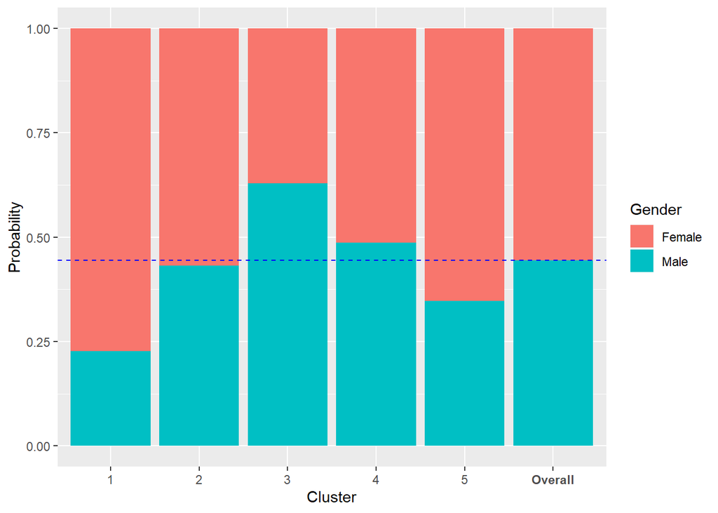

```r
gender_total <- rbind(complete_gender,cluster_gender)

gender_total <- gender_total %>%
  transform(Femaleprob = Female/(Female+Male))
gender_total <- gender_total %>%
  transform(Maleprob = Male/(Female+Male)) %>%
  select(-Female,-Male)
names(gender_total) <- c('Cluster','Female','Male')
gender_total %>%
  gather(Gender,Probability,-Cluster) %>%
  ggplot(aes(fill=Gender, y=Probability, x=Cluster)) +
  geom_bar(position="stack", stat="identity")+
  geom_hline(yintercept=0.445, linetype="dashed", color = "blue")+
  theme(axis.text.x = element_text(face = c('plain', 'plain', 'plain', 'plain', 'plain', 'bold')))
```

### **Discussion on Gender Distribition:**

### We can see from the above graph that the overall dataset has a pretty balanced gender distribution.

### Compared to the overall dataset, cluster 1 and 3 have the most deviation in gender distribution, where cluster 1 has significantly more females and cluster 3 more males.

### Cluster 5 also has more females but the extent is less extreme than cluster 1. Clusters 2 and 4 have similar gender distributions as in the overall dataset.

### **Recommendations:**

### 1. Cluster 4 would be the group to promote to because this group generally earns high income and spends frequently. This means that members in cluster 4 could be relatively price insensitive. The average age of this group is 32.7. They’re likely young professionals who are financially independent. Acme can promote creative, popular, and high-quality products to this group.

### 2. Cluster 3 has high income but is conservative in spending. Acme should try to find out why these people don’t spend at its stores. It could be that Acme’s products don’t appeal to these people. We can see that the average of of cluster 3 is 41.1. So these people can be heads of families. They might be more attracted to more family-focused products such as boats.

### 3. Cluster 5 has low income and doesn’t like spending. To incentivize more spending from this group, Acme can consider strategies such as wholesale and ‘everyday low price’.